# Hugo Nuo

Hugo Nuo is an responsive light & clean hugo theme for blogger. This theme features several page layout, like an [about page](https://laozhu.me/about/) for your portfolio, a [links page](https://laozhu.me/links/) for your friends’ blog, a [tags page](https://laozhu.me/tags/) for your tags cloud, a works page is under development. This theme makes many third-party hugo shortcodes, including [Codepen](https://codepen.io/), [JSFiddle](https://jsfiddle.net/), [Video.js](http://videojs.com/), Music 163 and [Sheng Xiang](https://ppt.baomitu.com/), [Asciinema](https://asciinema.org/).

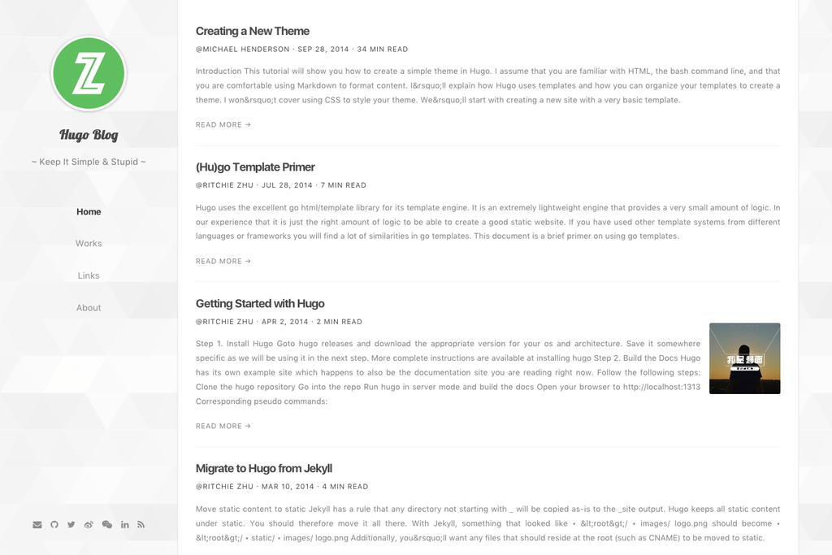

Hugo Nuo Theme Screenshot

Or you want → [A Real Site Demo](https://laozhu.me) | [Hugo Nuo Theme Post Preview](https://laozhu.me/post/hugo-nuo-post-preview/)

[中文帮助](https://laozhu.me/post/hugo-nuo-theme/)

## Installation

Inside the folder of your Hugo site run:

```bash
$ cd themes
$ git clone https://github.com/laozhu/hugo-nuo

# Change theme field to 'hugo-nuo' in your config.toml
# Or just copy exampleSite/config.toml
```

*For more information read the official [setup guide](https://gohugo.io/overview/installing/) of Hugo.*

## Getting Started

After installing the hugo-nuo theme successfully it requires just a few more steps to get your site finally running.

### The config file

Take a look inside the exampleSite folder of this theme. You’ll find a file called config.toml. To use it, copy the config.toml in the root folder of your Hugo site. Feel free to customize this theme as you like.

**Main Menu**

The hugo-nuo theme add `home`, `works` and `tags` page to initial site menu, you can add your own menu item here.

```
[[menu.main]]
  name = "Home"
  weight = 10
  identifier = "home"
  url = "/"

[[menu.main]]
  name = "Works"
  weight = 20
  identifier = "works"
  url = "https://github.com/laozhu"

[[menu.main]]
  name = "Tags"
  weight = 30
  identifier = "tags"
  url = "/tags/"
```

Or you can add some other page to menu in page’s front matter:

```markdown
---
title: 'Links'
date: 2017-08-02
layout: 'links'
menu: 'main'
weight: 40
---
```

**Social Networks**

The following social network icons are available:

```
[params]
  email = "name@domain.com"
  github = "github_username"
  twitter = "twitter_username"
  linkedin = "linkedin_username"
  weibo = "weibo_username"
  wechat= "/images/qrcode.jpg" # Replace with your wechat qrcode image
  facebook = "facebook_username"
  google = "googlplus_id_number"
  instagram = "instagram_username"
  youtube = "youtube_username"
  vimeo = "vimeo_username"
  medium = "medium_username"
  quora = "quora_username"
  pinterest = "pinterest_username"
  dribbble = "dribbble_username"
  behance = "behance_username"
  jsfiddle = "jsfiddle_username"
  codepen = "codepen_username"
  zhihu = "zhihu_username"
  douban = "douban_username"
  bilibili = "bilibili_id_number"
  codesandbox = "codesandbox_username"
  stackoverflow = "stackoverflow_username"
  npm = "npm_username"
  reddit = "reddit_username"
```

You can choose someone to display, the recommend number is 7 icons.

Icons are provided by [iconfont](https://www.iconfont.cn/) by default, but you can choose to use [FontAwesome](https://fontawesome.com/) instead by adding `fontAwesome = true` to the `[params]` section.

**SEO**

The hugo-nuo theme support [Google](https://www.google.com/webmasters/), [Bing](https://www.bing.com/toolbox/webmaster/), [Baidu](https://zhanzhang.baidu.com/), [Sogou](http://zhanzhang.sogou.com/), [360](http://zhanzhang.so.com/) webmaster’s meta verification tool, you can activate as required. The `seotitle` and `description` will show in search results and browser title.

```
[params]
  seotitle = "Hugo Blog Title (SEO Version)"
  description = "Hugo is one of the most popular open-source static site generators. With its amazing speed and flexibility, Hugo makes building websites fun again."

  # Google Webmaster
  # https://www.google.com/webmasters/
  googleSiteVerification = "google_site_verification_code"

  # Bing Webmaster
  # https://www.bing.com/toolbox/webmaster/
  msValidate = "bing_site_verification_code"

  # Baidu Webmaster (China Only)
  # https://zhanzhang.baidu.com/
  # baiduSiteVerification = "baidu_site_verification_code"

  # Sogou Webmaster (China Only)
  # http://zhanzhang.sogou.com/
  # sogouSiteVerification = "sogou_site_verification_code"

  # 360 Webmaster (China Only)
  # http://zhanzhang.so.com/
  # soSiteVerification = "360_site_verification_code"
```

**Website Analytics**

The hugo-nuo theme support [Google Analytics](https://www.google.com/analytics/) and [Baidu Tongji](https://tongji.baidu.com/), In China you can choose both Baidu Tongji and Google Analytics.

```
# Google Analytics UA number
googleAnalytics = "UA-XXXXXXXX-X"

[params]
  # Baidu Tongji (China Only)
  # https://tongji.baidu.com/
  baiduTongji = "baidu_tongji_code"
```

**Social Comments**

The hugo-nuo theme support [Disqus](https://disqus.com/) and [Chang Yan](https://changyan.kuaizhan.com/) social comment system, In China you can choose Chang Yan because Disqus is blocked by GFW.

```
# Disqus Username
disqusShortname = "disqus_shortname"

[params]
  # Changyan Comments (China Only)
  changyan = false
  changyanId = "your_changyan_id"
  changyanConf = "your_changyan_conf"
```

If you want to use Disqus, you should disable `changyan` to `false`.

**🆕 Medium Zoom**

If you want medium-like photo zoom in your post, you can add `zoomable` class to your `img` or `figure` tag, just something like below:

```html
<img src="/media/posts/hugo-nuo-post-preview/01.jpg" class="zoomable">
```

```markdown
{{% figure src="/media/posts/hugo-nuo-post-preview/01.jpg" alt="这是一只梅花鹿" title="显然，这是一只梅花鹿" class="zoomable" %}}
```

### The works page

The works page layout is under development, you can use github homepage for replacement temporarily.

```
[[menu.main]]
  name = "Works"
  weight = 20
  identifier = "works"
  url = "https://github.com/your_github_username"
```

### The tags page

Thanks to [@bwangelme](https://github.com/bwangelme)’s great [PR](https://github.com/laozhu/hugo-nuo/pull/37), the tags page has been done, you can use this page by adding it to main menu.

```
[[menu.main]]
  name = "Tags"
  weight = 30
  identifier = "tags"
  url = "/tags/"
```

### The links page

Inside the folder of your Hugo site run:

```bash
$ hugo new links.md
$ mkdir data && touch data/links.yml
$ mkdir -p content/media/links
$ vim content/links.md
```

Change the content of `links.md`, set page layout to `links`, If you want to add about page to menu, set menu to `main` and `weight` to 40.

```markdown
---
title: 'Links'
date: 2017-08-02
layout: 'links'
menu: 'main'
weight: 40
---
```

The links page read data from `data/links.toml` file, now you can add friend’s links there. The format looks like:

```
[chekun]
  title = "chekun's blog"
  link = "https://chekun.me"
  avatar = "/media/links/chekun.jpg"
  description = "A full-stack developer"

[wangbo]
  title = "Boof Wang"
  link = "http://boof.wang"
  avatar = "/media/links/wangbo.jpg"
  description = "Another full-stack developer"
```

The links page need friend’s avatar, finally you should add friend’s avatar to `content/media/links` directory and link to avatar in the `links.toml` file.

### The about page

Inside the folder of your Hugo site run:

```bash
$ hugo new about.md
$ vim content/about.md
```

Change the content of `about.md`, set page layout to `about`, If you want to add about page to menu, set menu to `main` and `weight` to 50.

```markdown
---
title: 'About'
date: 2017-08-02
layout: 'about'
menu: 'main'
weight: 50
comments: false
---

Write something about you here.
```

Write your portfolio as a post here, if you want comments in about page, you should turn comments to `true`.

### The resume page

Inside the folder of your Hugo site run:

```bash
$ hugo new resume.md
$ cat << EOF > content/resume.md
---
title: "Resume"
date: 2017-12-01
layout: "resume"
---
EOF
```

Then create a file at `data/resume.toml`, where the resume page reads data from. You can reference exampleSite/data/resume.toml for how to construct your resume.

The resume page will be located at `/resume` off your website root. Different from the about page, the resume page is intended as a one pager that you can print out for job hunting.

## Custom theme

If you don’t want change default theme SCSS files, you can override styles with an custom SCSS file. Set file in your `config.toml` as below.

```
[params]
  # Overrid theme styles in this file
  customStyle = "styles/custom.scss"
```

Then create `styles/custom.scss` file and write your own styles there. your custom rules will override the default ones. you can place custom.scss in theme-scoped or site-scoped assets folder.

```
.
├── README.md
├── assets
│   └── styles
│       └── custom.scss ✅
├── config.toml
├── content
└── themes
    └── hugo-nuo
        ├── assets
            │   ├── images
            │   ├── scripts
            │   ├── service-worker.js
            │   └── styles
                    ├── partials
                    ├── main.scss
            │       └── custom.scss ✅
            └── theme.toml
```

If you want to change avatar or favicons without modifying this theme, just copy `themes/hugo-nuo/assets` and `themes/hugo-nuo/static` to your blog root dir and keep the filename the same with theme.

```bash
~/D/@/my-blog ❯❯❯ tree -L 2
.
├── config.toml
├── assets
│   └── images          <-- replace images
├── static
│   ├── favicon.ico     <-- replace favicon.ico
│   ├── icons           <-- replace icons
│   └── manifest.json
└── themes
    └── hugo-nuo
```

Above is your blog repo structure, now you can replace images with your own, and don’t need to modify theme anymore.

## Build

> **⚠️ Big Change**

> This theme has been using hugo pipes instead of webpack now, no build package needed now.

I use [ImageOptim](https://imageoptim.com/) to make images load faster, I recommend this tool to you.

*From Hugo 0.28, the default syntax hightlighter in Hugo is [Chroma](https://github.com/alecthomas/chroma); it is built in Go and is really, really fast – and for the most important parts compatible with [Pygments](http://pygments.org/).*

```bash
$ hugo gen chromastyles --style=monokai > ./src/styles/partials/syntax.css
```

Run hugo gen `chromastyles -h` for more options. See https://help.farbox.com/pygments.html for a gallery of available styles.

## Nearly finished

In order to see your site in action, run Hugo’s built-in local server.

```bash
$ hugo server
```

Now enter localhost:1313 in the address bar of your browser.

## Credits

- [Medium Zoom](https://medium-zoom.francoischalifour.com/)
- [Video.js](http://videojs.com/)
- [MathJax](https://www.mathjax.org/)
- [Smooth Scroll](https://github.com/cferdinandi/smooth-scroll)
- [jsDelivr](https://www.jsdelivr.com/)

Also thanks to [Steve Francia](https://github.com/spf13) for creating [Hugo](https://gohugo.io/) and the awesome community around the project.